# Project 1 for Reproducible Research

## Loading and preprocessing the data

```r
# Read in the data and make sure the date is a date class
dataIn <- read.csv("activity.csv")
dataIn$date <- as.Date(dataIn$date)


# Sum the number of steps by dates
dailySum <- aggregate(dataIn$steps, by = list(dataIn$date), sum)
```

## Make a histogram of the total number of steps per day

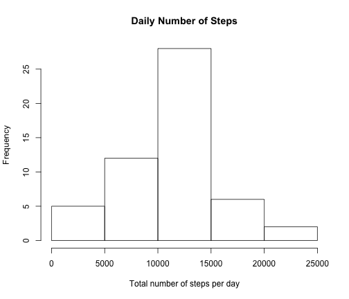

```r
hist(dailySum$x, xlab = "Total number of steps per day", main = "Daily Number of Steps")
```

## Calculate the mean and median number of steps per day

```r
meanSteps <- mean(dailySum$x, na.rm = TRUE)
medianSteps <- median(dailySum$x, na.rm = TRUE)
```

The mean number of steps per day is 1.0766 × 10<sup>4</sup>. The median number of steps per day is 10765.

## Make a time series plot (i.e. type = “l”) of the 5-minute interval (x-axis) and the average number of steps taken, averaged across all days (y-axis).

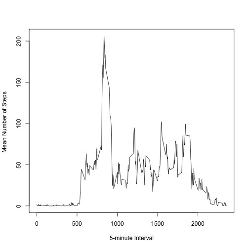

```r
intervalMean <- aggregate(dataIn$steps, by = list(dataIn$interval), mean, na.rm = TRUE)
plot(intervalMean$Group.1, intervalMean$x, type = "l", xlab = "5-minute Interval",
    ylab = "Mean Number of Steps ")
```

```r
maxInterval <- intervalMean[intervalMean$x == max(intervalMean$x), 1]
```

The interval with the greatest average number of steps across all days is interval 835.

## Inputing missing values

### Calculate and report the total number of missing values in the dataset (i.e. the total number of rows with NAs)

```r
numNa <- sum(is.na(dataIn$steps))
```

The dataset contains 2304 rows with missing values. For each missing value, we will substitue the mean value from that interval.

### Devise a strategy for filling in all of the missing values in the dataset. Create a new dataset that is equal to the original dataset but with the missing data filled in.

```r
dataInNoNa <- dataIn
for (i in 1:nrow(intervalMean)) {
    dataInNoNa$steps[dataInNoNa$interval == intervalMean$Group.1[i] & is.na(dataInNoNa$steps)] <- intervalMean$x[i]
}
```

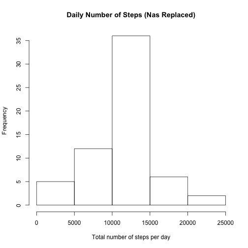

```r
dailySumNoNa <- aggregate(dataInNoNa$steps, by = list(dataInNoNa$date), sum)

hist(dailySumNoNa$x, xlab = "Total number of steps per day", main = "Daily Number of Steps (Nas Replaced)")
```

```r
meanStepsNoNa <- mean(dailySum$x, na.rm = TRUE)
medianStepsNoNa <- median(dailySum$x, na.rm = TRUE)
```

## Are there differences in activity patterns between weekdays and weekends?

### Create a new factor variable in the dataset with two levels – “weekday” and “weekend” indicating whether a given date is a weekday or weekend day.

```r
dataIn$WeekendWeekday <- "Weekday"
dataIn$WeekendWeekday[weekdays(dataIn$date) == "Saturday" | weekdays(dataIn$date) ==
    "Sunday"] <- "Weekend"
dataIn$WeekendWeekday <- as.factor(dataIn$WeekendWeekday)
```

### Make a panel plot containing a time series plot (i.e. type = “l”) of the 5-minute interval (x-axis) and the average number of steps taken, averaged across all weekday days or weekend days (y-axis).

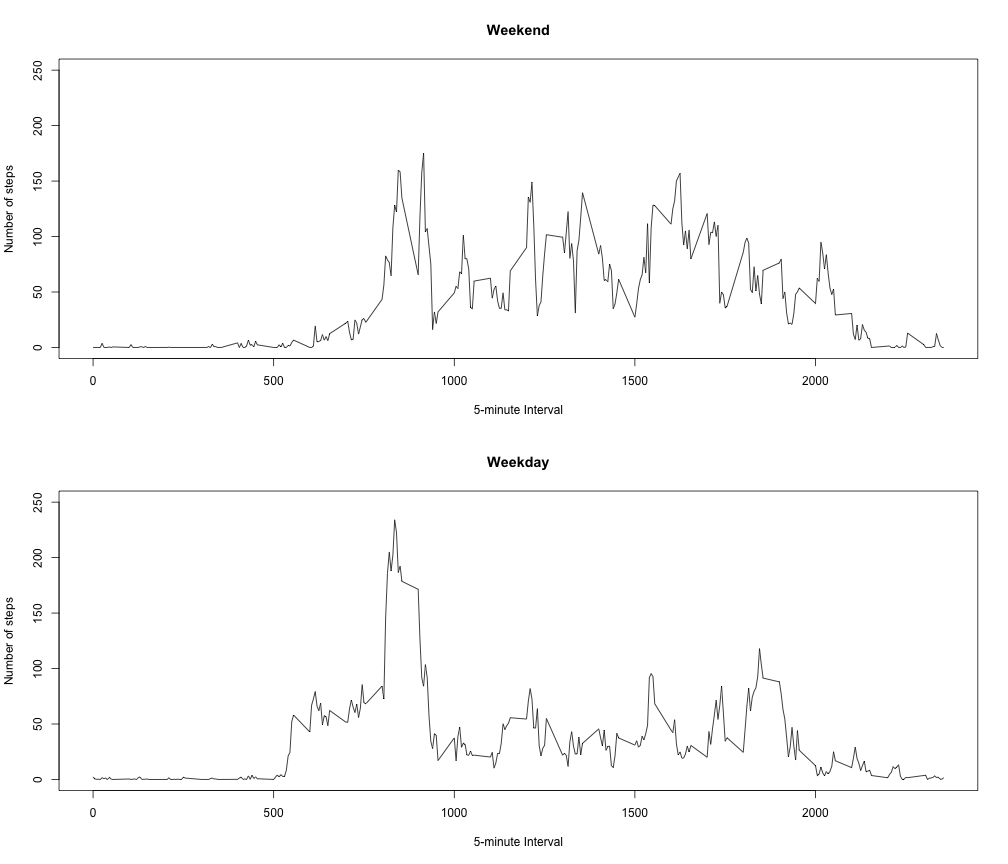

```r
weekendSteps <- aggregate(dataIn$steps[dataIn$WeekendWeekday == "Weekend"],
    by = list(dataIn$interval[dataIn$WeekendWeekday == "Weekend"]), mean, na.rm = TRUE)
weekdaySteps <- aggregate(dataIn$steps[dataIn$WeekendWeekday == "Weekday"],
    by = list(dataIn$interval[dataIn$WeekendWeekday == "Weekday"]), mean, na.rm = TRUE)

par(mfrow = c(2, 1))
plot(weekendSteps$Group.1, weekendSteps$x, ylab = "Number of steps", main = "Weekend",
    xlab = "5-minute Interval", type = "l", ylim = c(0, 250))

plot(weekdaySteps$Group.1, weekdaySteps$x, ylab = "Number of steps", main = "Weekday",
    xlab = "5-minute Interval", type = "l", ylim = c(0, 250))
```